# PML Project : Learning Algortithm for Personal Activiy Monitoring.

Georgy Ulukhanov

Monday, February 16, 2015

## Course Project Assignment

“Using devices such as Jawbone Up, Nike FuelBand, and Fitbit it is now possible to collect a large amount of data about personal activity relatively inexpensively. These type of devices are part of the quantified self movement ??? a group of enthusiasts who take measurements about themselves regularly to improve their health, to find patterns in their behavior, or because they are tech geeks. One thing that people regularly do is quantify how much of a particular activity they do, but they rarely quantify how well they do it. In this project, your goal will be to use data from accelerometers on the belt, forearm, arm, and dumbell of 6 participants. They were asked to perform barbell lifts correctly and incorrectly in 5 different ways. More information is available from the website here: http://groupware.les.inf.puc-rio.br/har (see the section on the Weight Lifting Exercise Dataset).”

## Data Sources

The training and test data for this project are available here:

https://d396qusza40orc.cloudfront.net/predmachlearn/pml-training.csv

https://d396qusza40orc.cloudfront.net/predmachlearn/pml-testing.csv

The original source of the data is: http://groupware.les.inf.puc-rio.br/har. If you use the document you create for this class for any purpose please cite them as they have been very generous in allowing their data to be used for this kind of assignment.

## Project Objectives

The goal of your project is to predict the manner in which they did the exercise. This is the “classe” variable in the training set. You may use any of the other variables to predict with. You should create a report describing how you built your model, how you used cross validation, what you think the expected out of sample error is, and why you made the choices you did. You will also use your prediction model to predict 20 different test cases. 1. Your submission should consist of a link to a Github repo with your R markdown and compiled HTML file describing your analysis. Please constrain the text of the writeup to < 2000 words and the number of figures to be less than 5. It will make it easier for the graders if you submit a repo with a gh-pages branch so the HTML page can be viewed online (and you always want to make it easy on graders :-). 2. You should also apply your machine learning algorithm to the 20 test cases available in the test data above. Please submit your predictions in appropriate format to the programming assignment for automated grading. See the programming assignment for additional details.

## Summary of the results

After removing NAs and some obviously unuseful variables from the “train” dataset and splitting it 70/30 we applied Decision Tree and Random Forest models. Random Forest model showed almost 100% accuracy, so we applied it to “test” dataset to predict missing “classe” variable

## Libraries and reproduceability

```r
library(caret)
```

```r
library(rpart)
library(rpart.plot)
library(randomForest)
set.seed(100)
```

## Read data

```r
test <- read.csv("pml-testing.csv",na.strings=c("NA",""))
train <- read.csv("pml-training.csv",na.strings=c("NA",""))
```

## Preprocessing

All preprocessing is made only to “train” set

```r
#we exclude first 7 columns as irrelevant to our study
train <- train[, -(1:7)]
dim(train)
```

```
## [1] 19622   153
```

```r
#we exclude variables with only NAs
train<-train[,colSums(is.na(train)) == 0]
dim(train)
```

```
## [1] 19622    53
```

## Split “train” to “subtrain” and “subtest” subsets

```r
inTrain <- createDataPartition(y=train$classe, p=0.7, list=FALSE)
subtrain <- train[inTrain, ]
subtest <- train[-inTrain, ]
dim(subtrain)
```

```
## [1] 13737    53
```

```r
dim(subtest)
```

```
## [1] 5885   53
```

## Train and test a model

We will compare Decision Tree and Random Forest models

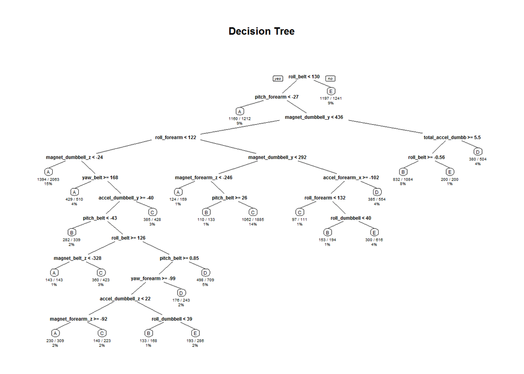

```r
#Decision Tree
#model creation
dtModel <- rpart(classe ~ ., data=subtrain, method="class")
#prediction
dtPrediction <- predict(dtModel, subtest[,-53], type = "class")
#plot of the Decision Tree
rpart.plot(dtModel, main="Decision Tree", extra=102, under=TRUE, faclen=0)
```

```r
# Test results on test subset:
confusionMatrix(dtPrediction, subtest$classe)
```

```
## Confusion Matrix and Statistics
##
##           Reference
## Prediction    A    B    C    D    E
##          A 1472  275   34  115   42
##          B   50  624   60   19   62
##          C   44  104  847  146  121
##          D   59   69   60  590   53
##          E   49   67   25   94  804
##
## Overall Statistics
##
##                Accuracy : 0.737
##                  95% CI : (0.7255, 0.7482)
##     No Information Rate : 0.2845
##     P-Value [Acc > NIR] : < 2.2e-16
##
##                   Kappa : 0.6656
##  Mcnemar's Test P-Value : < 2.2e-16
##
## Statistics by Class:
##
##                      Class: A Class: B Class: C Class: D Class: E
## Sensitivity            0.8793   0.5478   0.8255   0.6120   0.7431
## Specificity            0.8893   0.9598   0.9146   0.9510   0.9511
## Pos Pred Value         0.7595   0.7656   0.6712   0.7100   0.7738
## Neg Pred Value         0.9488   0.8984   0.9613   0.9260   0.9426
## Prevalence             0.2845   0.1935   0.1743   0.1638   0.1839
## Detection Rate         0.2501   0.1060   0.1439   0.1003   0.1366
## Detection Prevalence   0.3293   0.1385   0.2144   0.1412   0.1766
## Balanced Accuracy      0.8843   0.7538   0.8701   0.7815   0.8471
```

```r
#Random Forest
#model creation
rfModel <- randomForest(classe ~ ., data=subtrain, method="class")
#prediction
rfPrediction <- predict(rfModel, subtest[,-53], type = "class")
#plot of the Decision Tree
#plot(rfModel)
# Test results on test subset:
confusionMatrix(rfPrediction, subtest$classe)
```

```
## Confusion Matrix and Statistics
##
##           Reference
## Prediction    A    B    C    D    E
##          A 1673    6    0    0    0
##          B    1 1133    4    0    0
##          C    0    0 1020   13    2
##          D    0    0    2  950    0
##          E    0    0    0    1 1080
##
## Overall Statistics
##
##                Accuracy : 0.9951
##                  95% CI : (0.9929, 0.9967)
##     No Information Rate : 0.2845
##     P-Value [Acc > NIR] : < 2.2e-16
##
##                   Kappa : 0.9938
##  Mcnemar's Test P-Value : NA
##
## Statistics by Class:
##
##                      Class: A Class: B Class: C Class: D Class: E
## Sensitivity            0.9994   0.9947   0.9942   0.9855   0.9982
## Specificity            0.9986   0.9989   0.9969   0.9996   0.9998
## Pos Pred Value         0.9964   0.9956   0.9855   0.9979   0.9991
## Neg Pred Value         0.9998   0.9987   0.9988   0.9972   0.9996
## Prevalence             0.2845   0.1935   0.1743   0.1638   0.1839
## Detection Rate         0.2843   0.1925   0.1733   0.1614   0.1835
## Detection Prevalence   0.2853   0.1934   0.1759   0.1618   0.1837
## Balanced Accuracy      0.9990   0.9968   0.9955   0.9925   0.9990
```

## Final Predicting

```r
rfPredictFinal <- predict(rfModel, test, type="class")
rfPredictFinal
```

```
##  1  2  3  4  5  6  7  8  9 10 11 12 13 14 15 16 17 18 19 20
##  B  A  B  A  A  E  D  B  A  A  B  C  B  A  E  E  A  B  B  B
## Levels: A B C D E
```

## Submission file

```r
pml_write_files = function(x){
  n = length(x)
  for(i in 1:n){
    filename = paste0("problem_id_",i,".txt")
    write.table(x[i],file=filename,quote=FALSE,row.names=FALSE,col.names=FALSE)
  }
}

#pml_write_files(rfPredictFinal)
```